# Trabalho de Grupo - MBIOINF

### Depressão com o uso de internet

H0: O grau de depressão nao é correlacionado com o numero de horas médias por semana de uso de internet do participante.  
H1: O grau de depressão é correlacionado com o numero de horas médias por semana de uso de internet do participante.

```r
model=lm(dati$Internet.use..mean.hours.per.week.~dati$DepressionAfter)
model
```

```
##
## Call:
## lm(formula = dati$Internet.use..mean.hours.per.week. ~ dati$DepressionAfter)
##
## Coefficients:
##          (Intercept)  dati$DepressionAfter
##                0.810                 2.444
```

```r
summary(model)
```

```
##
## Call:
## lm(formula = dati$Internet.use..mean.hours.per.week. ~ dati$DepressionAfter)
##
## Residuals:
##    Min     1Q Median     3Q    Max
## -6.997 -2.030 -1.054 -0.070 32.015
##
## Coefficients:
##                      Estimate Std. Error t value Pr(>|t|)
## (Intercept)            0.8100     0.6417   1.262  0.20881
## dati$DepressionAfter   2.4445     0.8303   2.944  0.00375 **
## ---
## Signif. codes:  0 '***' 0.001 '**' 0.01 '*' 0.05 '.' 0.1 ' ' 1
##
## Residual standard error: 4.833 on 153 degrees of freedom
## Multiple R-squared:  0.05361,    Adjusted R-squared:  0.04743
## F-statistic: 8.667 on 1 and 153 DF,  p-value: 0.003745
```

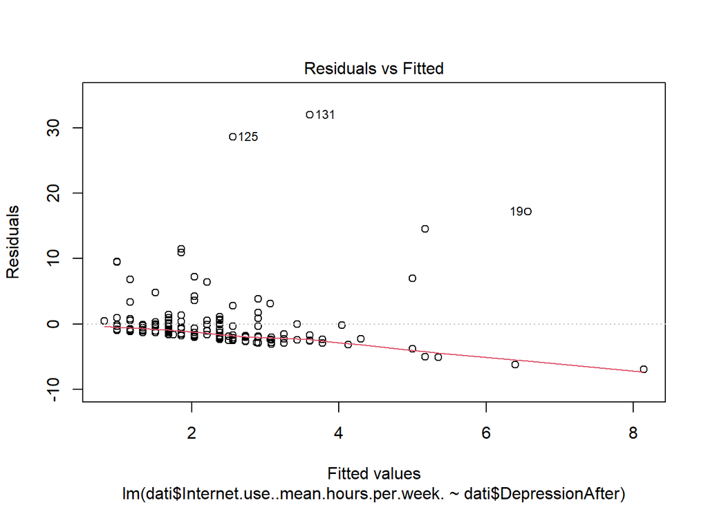

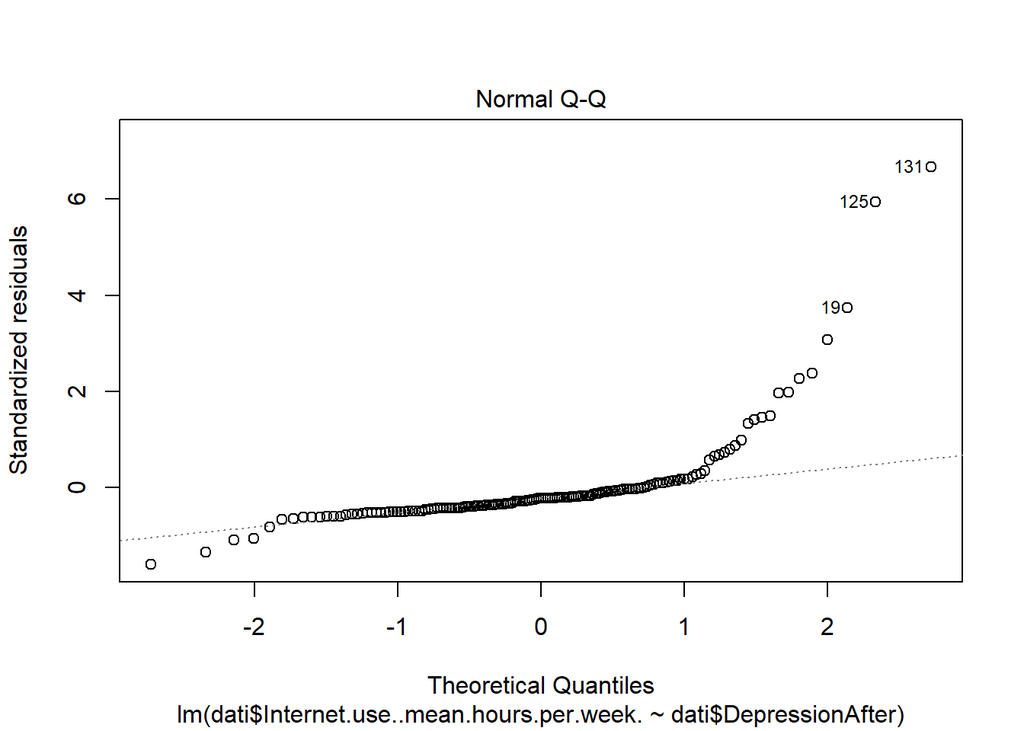

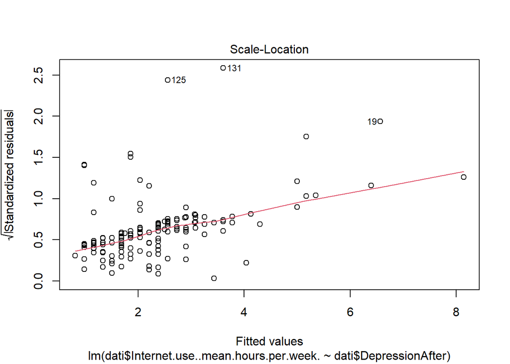

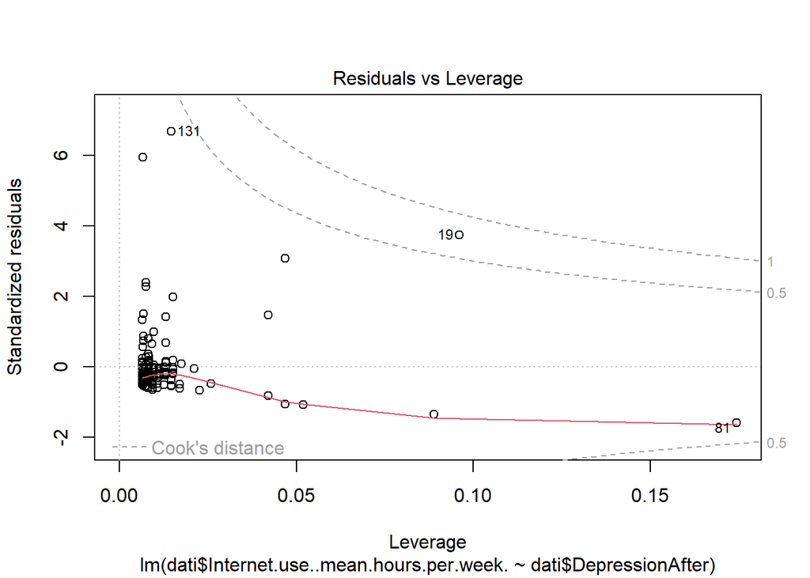

```r
plot(model)
```

Como o p-value é menor do que 0.05, podemos rejeitar a H0, pelo que há evidencia que nos indica uma correlação do grau de depressão com o o numero de horas médias por semana de uso de internet do participante.  
Aqui o grafico dos valores residuais apresentam um afastamento deveras grande da linha do 0, pelo que nos indica que a qualidade do ajuste deste modelo é má. Para tentarmos contornar esta situação recorremos ao modelo exponencial e logaritmico mas não foi possivel a sua execução uma vez que ao exponenciarmos ou logaritimizarmos os valores, havia alguns que forneciam o valor de infinito, impossibilitando a criação do grafico.

## Depressão Antes e Após

H0: O grau de depressão antes do uso de internet não é correlacionado com o grau de depressão depois do uso de internet.  
H1: O grau de depressão antes do uso de internet é correlacionado com o grau de depressão depois do uso de internet.

```r
modelab = lm(da~db)
modelab
```

```
##
## Call:
## lm(formula = da ~ db)
##
## Coefficients:
## (Intercept)           db
##      0.3938       0.3021
```

```r
summary(modelab)
```

```
##
## Call:
## lm(formula = da ~ db)
##
## Residuals:
##      Min       1Q   Median       3Q      Max
## -0.94661 -0.25460 -0.05493  0.14107  2.48535
##
## Coefficients:
##             Estimate Std. Error t value Pr(>|t|)
## (Intercept)  0.39383    0.06407   6.147 6.57e-09 ***
## db           0.30208    0.07241   4.172 5.05e-05 ***
## ---
## Signif. codes:  0 '***' 0.001 '**' 0.01 '*' 0.05 '.' 0.1 ' ' 1
##
## Residual standard error: 0.4459 on 153 degrees of freedom
## Multiple R-squared:  0.1021, Adjusted R-squared:  0.09626
## F-statistic:  17.4 on 1 and 153 DF,  p-value: 5.048e-05
```

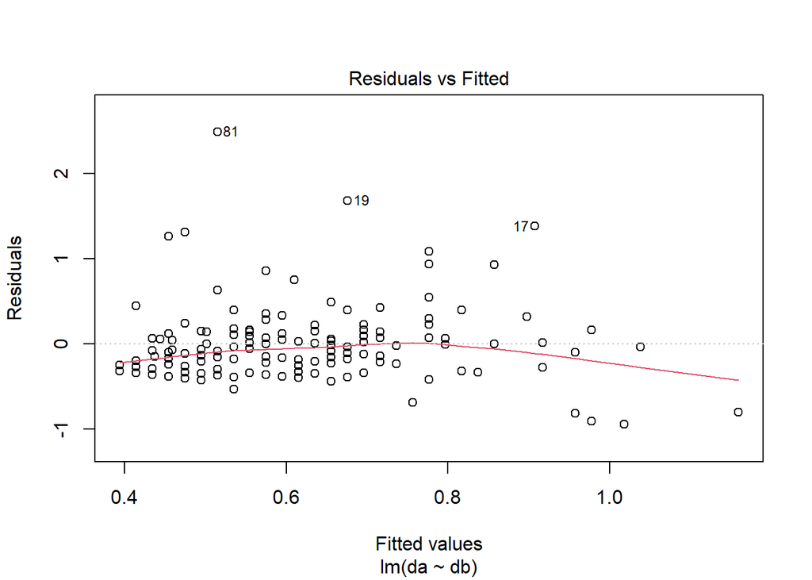

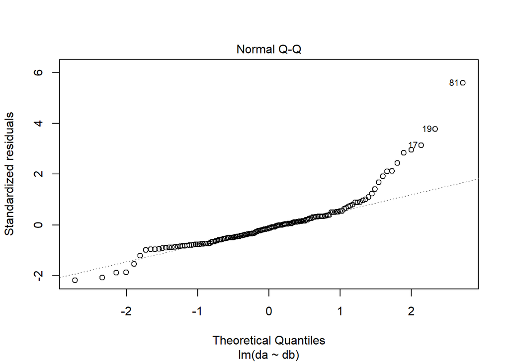

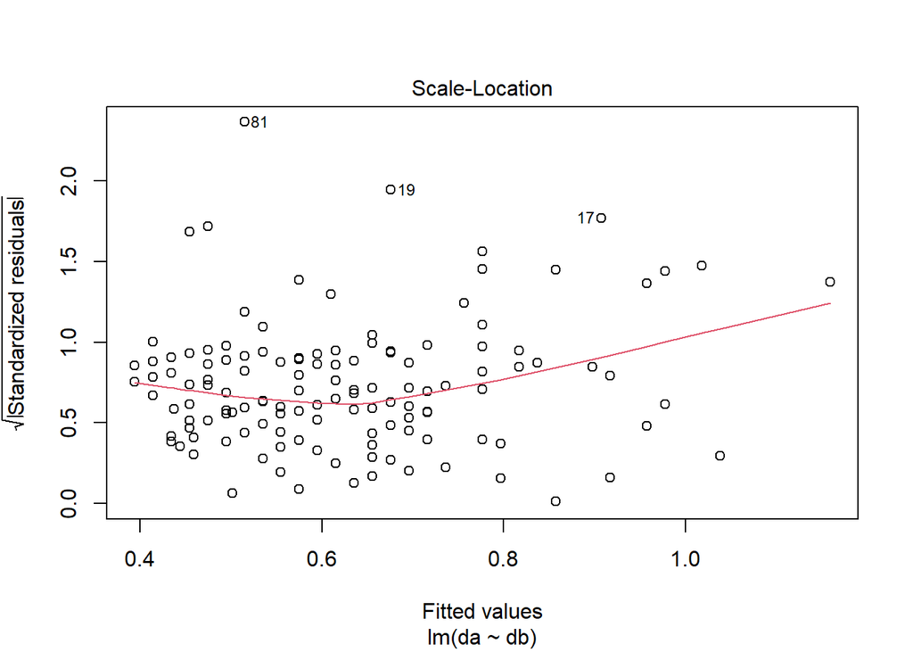

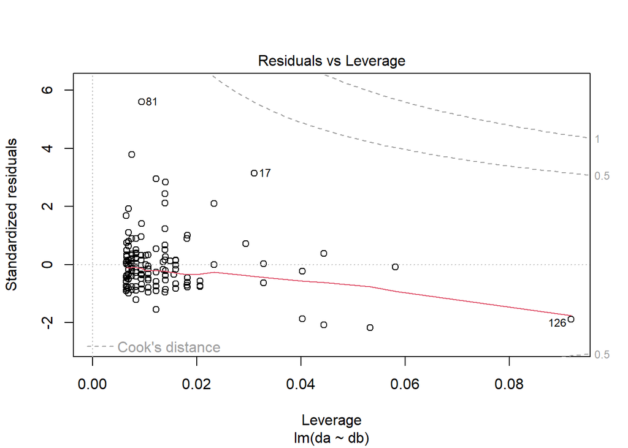

```r
plot(modelab)
```

Como o p-value é menor do que 0.05, podemos rejeitar a H0, pelo que há evidencia da existência de uma correlação do grau de depressão antes do uso de internet com o grau de depressão depois do uso de internet.

# Correlações com interações de variáveis

## Depression After

### Depressão com horas de uso por genero

H0: O grau de depressão depois do uso de internet não é correlacionado com o número médio de horas de uso de internet por semana e o género.  
H1: O grau de depressão depois do uso de internet é correlacionado com o número médio de horas de uso de internet por semana e o género.

```r
model21 = lm(da~dati$Internet.use..mean.hours.per.week.+dati$Gender)
model21
```

```
##
## Call:
## lm(formula = da ~ dati$Internet.use..mean.hours.per.week. + dati$Gender)
##
## Coefficients:
##                             (Intercept)
##                                 0.57848
## dati$Internet.use..mean.hours.per.week.
##                                 0.02196
##                         dati$Gendermale
##                                -0.03152
```

```r
summary (model21)
```

```
##
## Call:
## lm(formula = da ~ dati$Internet.use..mean.hours.per.week. + dati$Gender)
##
## Residuals:
##      Min       1Q   Median       3Q      Max
## -0.73824 -0.31863 -0.07757  0.19876  2.39636
##
## Coefficients:
##                                         Estimate Std. Error t value Pr(>|t|)
## (Intercept)                              0.57848    0.05207  11.109   <2e-16
## dati$Internet.use..mean.hours.per.week.  0.02196    0.00747   2.940   0.0038
## dati$Gendermale                         -0.03152    0.07430  -0.424   0.6720
##
## (Intercept)                             ***
## dati$Internet.use..mean.hours.per.week. **
## dati$Gendermale
## ---
## Signif. codes:  0 '***' 0.001 '**' 0.01 '*' 0.05 '.' 0.1 ' ' 1
##
## Residual standard error: 0.459 on 152 degrees of freedom
## Multiple R-squared:  0.05473,    Adjusted R-squared:  0.04229
## F-statistic:   4.4 on 2 and 152 DF,  p-value: 0.01387
```

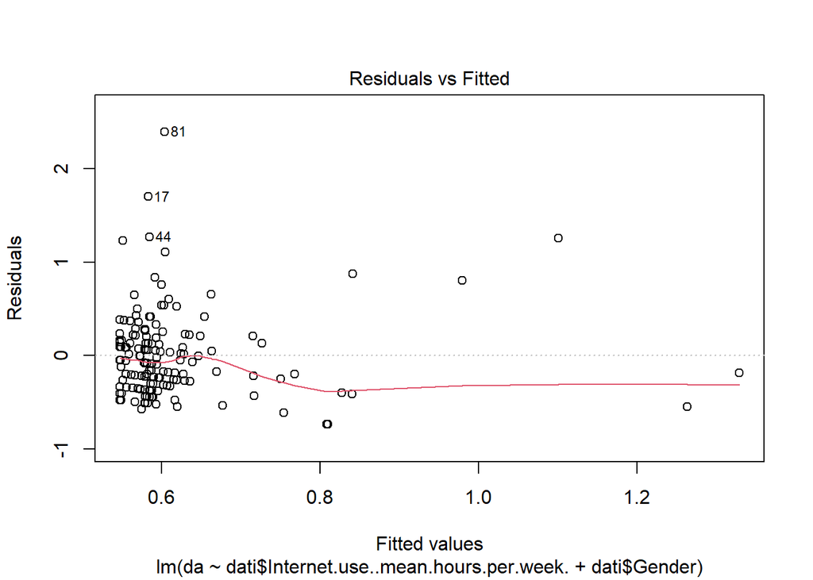

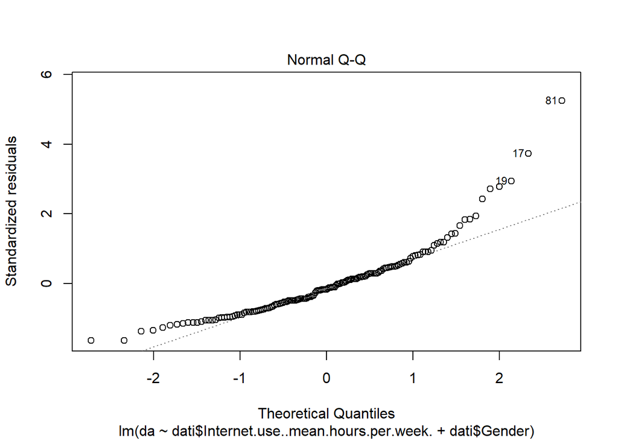

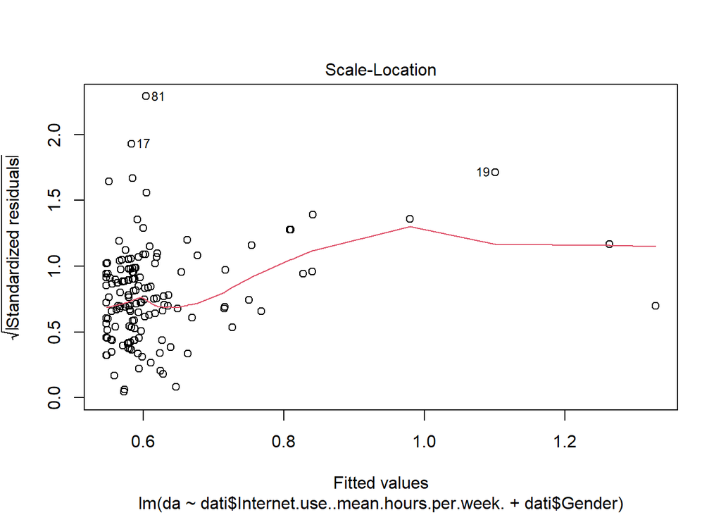

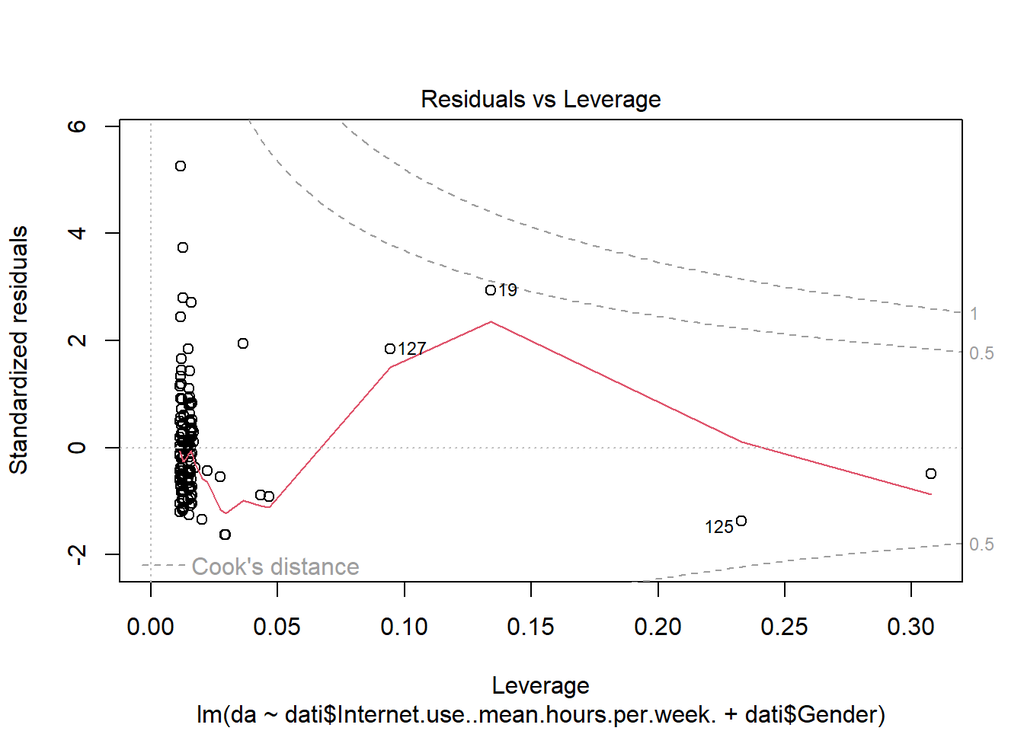

```r
plot(model21)
```

Como o p-value é menor do que 0.05, podemos rejeitar a H0, pelo que há evidencias que nos pode indicar uma correlação do grau de depressão com o número médio de horas de uso de internet por semana e o género do participante.

### Depressão com horas de uso por etnia

H0: O grau de depressão depois do uso de internet não é correlacionado com o número médio de horas de uso de internet por semana e a etnia.  
H1: O grau de depressão depois do uso de internet é correlacionado com o número médio de horas de uso de internet por semana e a etnia.

```r
model22 = lm (da~dati$Internet.use..mean.hours.per.week.+dati$Race..white...1..minority...0.)
model22
```

```
##
## Call:
## lm(formula = da ~ dati$Internet.use..mean.hours.per.week. + dati$Race..white...1..minority...0.)
##
## Coefficients:
##                             (Intercept)
##                                 0.69148
## dati$Internet.use..mean.hours.per.week.
##                                 0.02377
##     dati$Race..white...1..minority...0.
##                                -0.16784
```

```r
summary(model22)
```

```
##
## Call:
## lm(formula = da ~ dati$Internet.use..mean.hours.per.week. + dati$Race..white...1..minority...0.)
##
## Residuals:
##      Min       1Q   Median       3Q      Max
## -0.70246 -0.31005 -0.04882  0.17700  2.28128
##
## Coefficients:
##                                          Estimate Std. Error t value Pr(>|t|)
## (Intercept)                              0.691485   0.078287   8.833 2.32e-15
## dati$Internet.use..mean.hours.per.week.  0.023767   0.007452   3.190  0.00173
## dati$Race..white...1..minority...0.     -0.167843   0.088878  -1.888  0.06087
##
## (Intercept)                             ***
## dati$Internet.use..mean.hours.per.week. **
## dati$Race..white...1..minority...0.     .
## ---
## Signif. codes:  0 '***' 0.001 '**' 0.01 '*' 0.05 '.' 0.1 ' ' 1
##
## Residual standard error: 0.454 on 152 degrees of freedom
## Multiple R-squared:  0.07531,    Adjusted R-squared:  0.06314
## F-statistic: 6.189 on 2 and 152 DF,  p-value: 0.002605
```

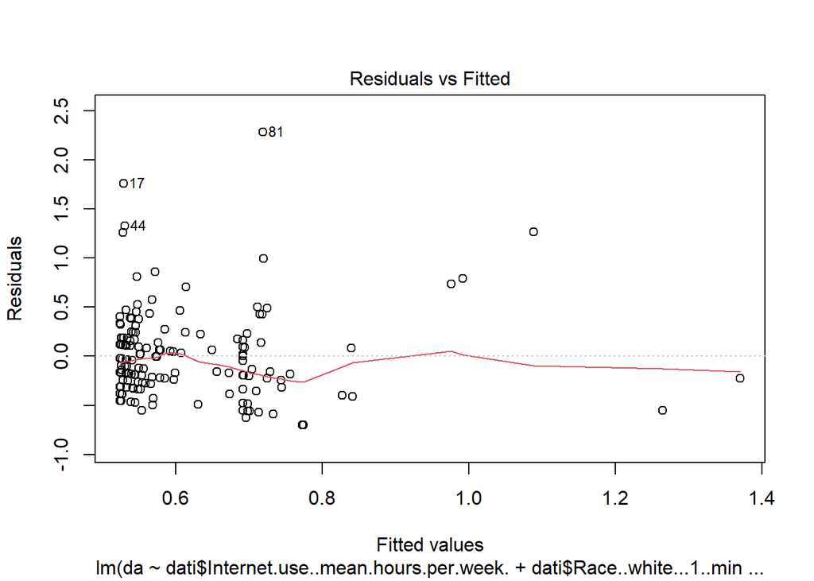

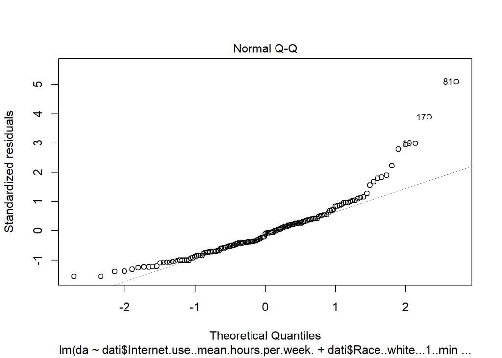

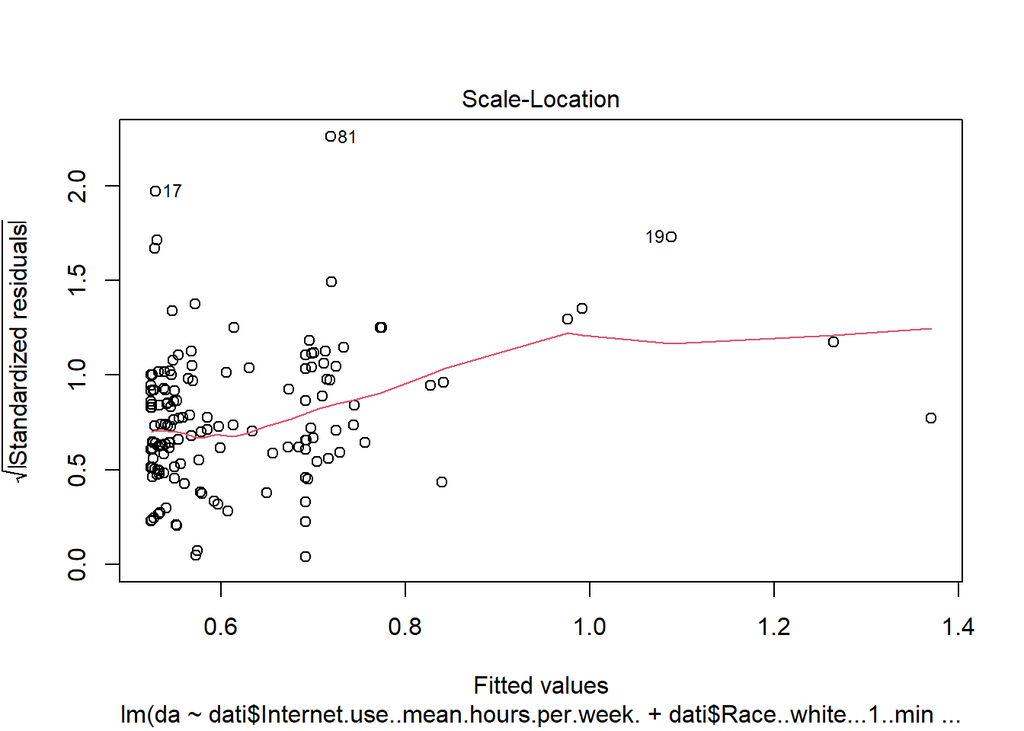

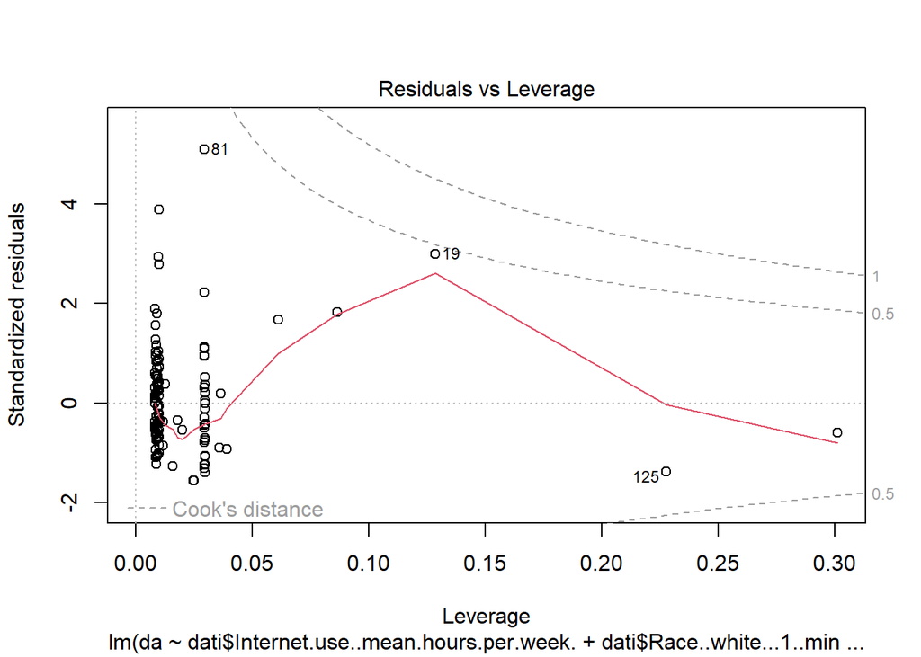

```r
plot(model22)
```

Como o p-value é menor do que 0.05, podemos rejeitar a H0, pelo que há evidencias que nos pode indicar uma correlação do grau de depressão com o número médio de horas de uso de internet por semana e a etnia do participante.

### Depressão com horas de uso por idade

H0: O grau de depressão depois do uso de internet não é correlacionado com o número médio de horas de uso de internet por semana e o estágio de vida.  
H1: O grau de depressão depois do uso de internet é correlacionado com o número médio de horas de uso de internet por semana e o estágio de vida.

```r
model23 = lm(da~dati$Internet.use..mean.hours.per.week.+dati$Age)
model23
```

```
##
## Call:
## lm(formula = da ~ dati$Internet.use..mean.hours.per.week. + dati$Age)
##
## Coefficients:
##                             (Intercept)
##                                 0.54580
## dati$Internet.use..mean.hours.per.week.
##                                 0.01989
##                            dati$AgeTeen
##                                 0.09389
```

```r
summary(model23)
```

```
##
## Call:
## lm(formula = da ~ dati$Internet.use..mean.hours.per.week. + dati$Age)
##
## Residuals:
##      Min       1Q   Median       3Q      Max
## -0.77772 -0.31366 -0.05303  0.16682  2.43140
##
## Coefficients:
##                                         Estimate Std. Error t value Pr(>|t|)
## (Intercept)                             0.545801   0.044241  12.337   <2e-16
## dati$Internet.use..mean.hours.per.week. 0.019893   0.007684   2.589   0.0106
## dati$AgeTeen                            0.093886   0.087397   1.074   0.2844
##
## (Intercept)                             ***
## dati$Internet.use..mean.hours.per.week. *
## dati$AgeTeen
## ---
## Signif. codes:  0 '***' 0.001 '**' 0.01 '*' 0.05 '.' 0.1 ' ' 1
##
## Residual standard error: 0.4575 on 152 degrees of freedom
## Multiple R-squared:  0.06074,    Adjusted R-squared:  0.04838
## F-statistic: 4.915 on 2 and 152 DF,  p-value: 0.008543
```

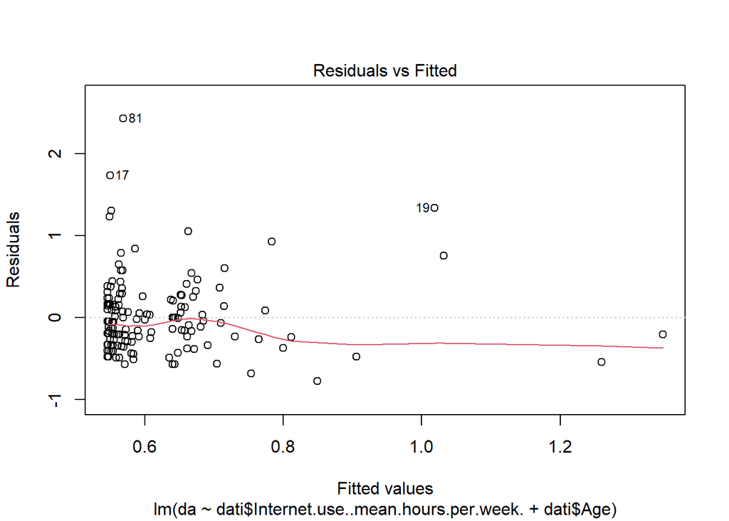

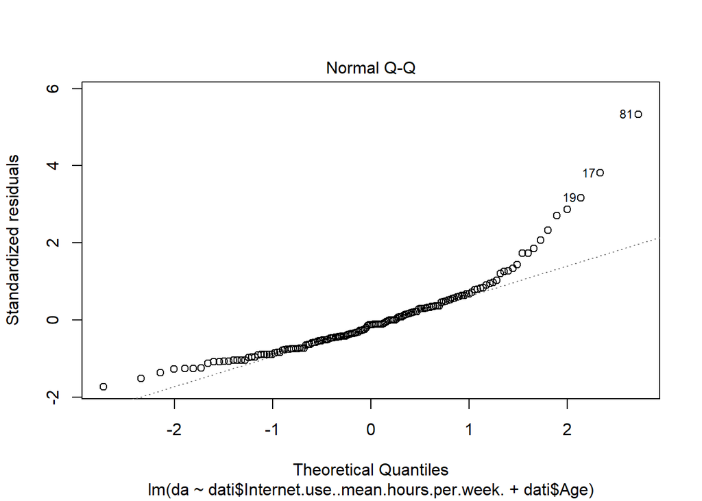

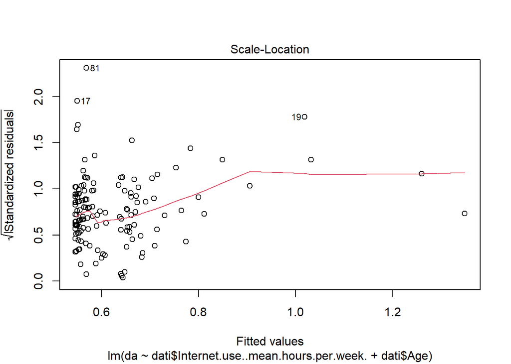

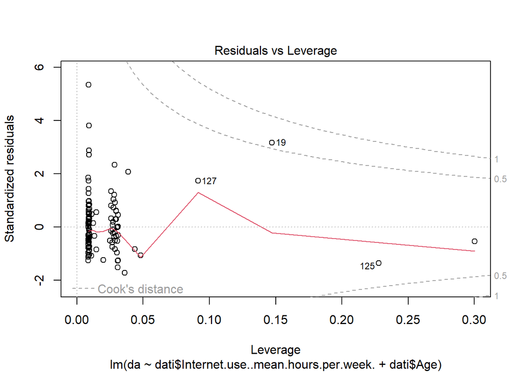

```r
plot(model23)
```

Como o p-value é menor do que 0.05, podemos rejeitar a H0, pelo que há evidencias que nos pode indicar uma correlação do grau de depressão com o número médio de horas de uso de internet por semana e o estágio de vida do participante.

### Depressao com horas de uso por salário

H0: O grau de depressão depois do uso de internet não é correlacionado com o número médio de horas de uso de internet por semana e o salário anual do agregado familiar.  
H1: O grau de depressão depois do uso de internet é correlacionado com o número médio de horas de uso de internet por semana e o salário anual do agregado familiar.

```r
model24 = lm(da~dati$Internet.use..mean.hours.per.week.+dati$Household.income...000.)
model24
```

```
##
## Call:
## lm(formula = da ~ dati$Internet.use..mean.hours.per.week. + dati$Household.income...000.)
##
## Coefficients:
##                             (Intercept)
##                                0.620313
## dati$Internet.use..mean.hours.per.week.
##                                0.021874
##            dati$Household.income...000.
##                               -0.001018
```

```r
summary(model24)
```

```
##
## Call:
## lm(formula = da ~ dati$Internet.use..mean.hours.per.week. + dati$Household.income...000.)
##
## Residuals:
##     Min      1Q  Median      3Q     Max
## -0.7156 -0.3127 -0.0699  0.1976  2.3851
##
## Coefficients:
##                                          Estimate Std. Error t value Pr(>|t|)
## (Intercept)                              0.620313   0.097457   6.365 2.19e-09
## dati$Internet.use..mean.hours.per.week.  0.021874   0.007465   2.930  0.00391
## dati$Household.income...000.            -0.001018   0.001621  -0.628  0.53100
##
## (Intercept)                             ***
## dati$Internet.use..mean.hours.per.week. **
## dati$Household.income...000.
## ---
## Signif. codes:  0 '***' 0.001 '**' 0.01 '*' 0.05 '.' 0.1 ' ' 1
##
## Residual standard error: 0.4587 on 152 degrees of freedom
## Multiple R-squared:  0.05606,    Adjusted R-squared:  0.04364
## F-statistic: 4.514 on 2 and 152 DF,  p-value: 0.01247
```

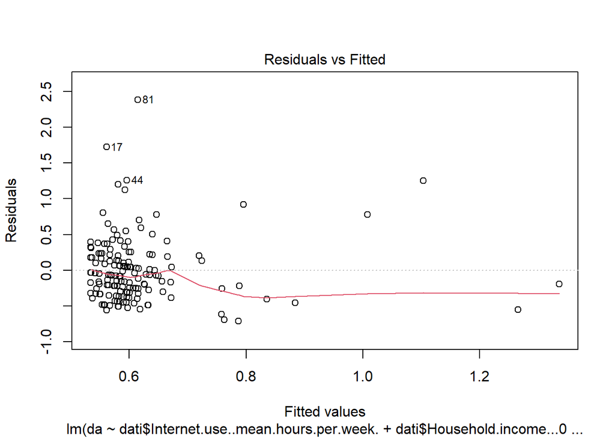

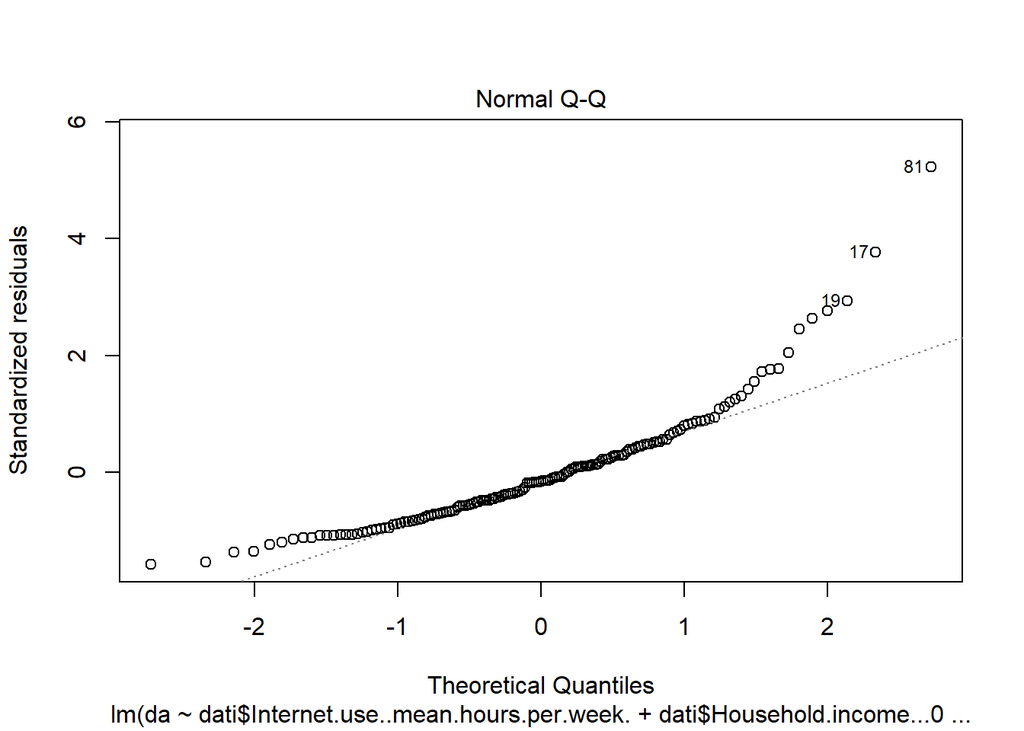

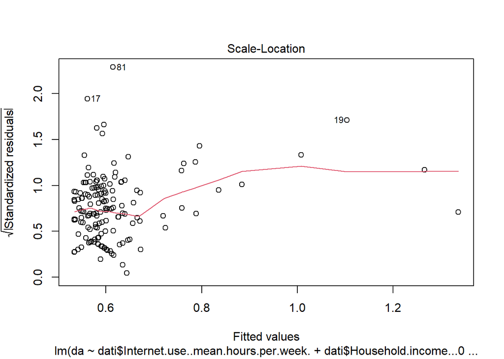

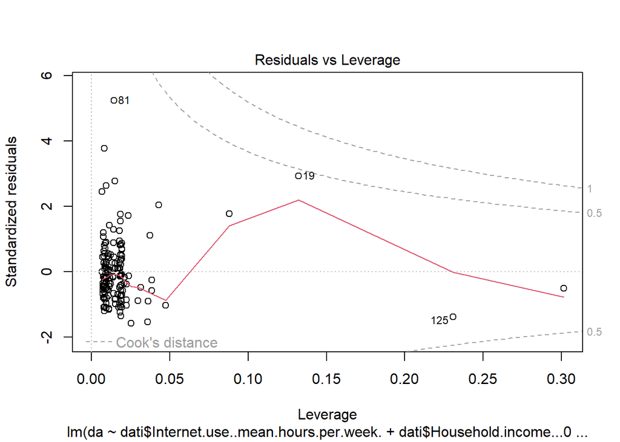

```r
plot(model24)
```

Como o p-value é menor do que 0.05, podemos rejeitar a H0, pelo que há evidencias que nos pode indicar uma correlação do grau de depressão com o número médio de horas de uso de internet por semana e o salário anual do agregado familiar do participante.

### Depressão com horas de uso por tamanho do agregado

H0: O grau de depressão depois do uso de internet não é correlacionado com o número médio de horas de uso de internet por semana e o tamanho do agregado familiar.  
H1: O grau de depressão depois do uso de internet é correlacionado com o número médio de horas de uso de internet por semana e o tamanho do agregado familiar.

```r
model25 = lm (da~dati$Internet.use..mean.hours.per.week.+dati$Household.size)
model25
```

```
##
## Call:
## lm(formula = da ~ dati$Internet.use..mean.hours.per.week. + dati$Household.size)
##
## Coefficients:
##                             (Intercept)
##                                 0.64693
## dati$Internet.use..mean.hours.per.week.
##                                 0.02169
##                     dati$Household.size
##                                -0.02152
```

```r
summary(model25)
```

```
##
## Call:
## lm(formula = da ~ dati$Internet.use..mean.hours.per.week. + dati$Household.size)
##
## Residuals:
##      Min       1Q   Median       3Q      Max
## -0.71774 -0.32235 -0.06156  0.18848  2.34974
##
## Coefficients:
##                                         Estimate Std. Error t value Pr(>|t|)
## (Intercept)                              0.64693    0.12417   5.210 6.06e-07
## dati$Internet.use..mean.hours.per.week.  0.02169    0.00747   2.903  0.00425
## dati$Household.size                     -0.02152    0.03071  -0.701  0.48447
##
## (Intercept)                             ***
## dati$Internet.use..mean.hours.per.week. **
## dati$Household.size
## ---
## Signif. codes:  0 '***' 0.001 '**' 0.01 '*' 0.05 '.' 0.1 ' ' 1
##
## Residual standard error: 0.4585 on 152 degrees of freedom
## Multiple R-squared:  0.05666,    Adjusted R-squared:  0.04425
## F-statistic: 4.565 on 2 and 152 DF,  p-value: 0.01188
```

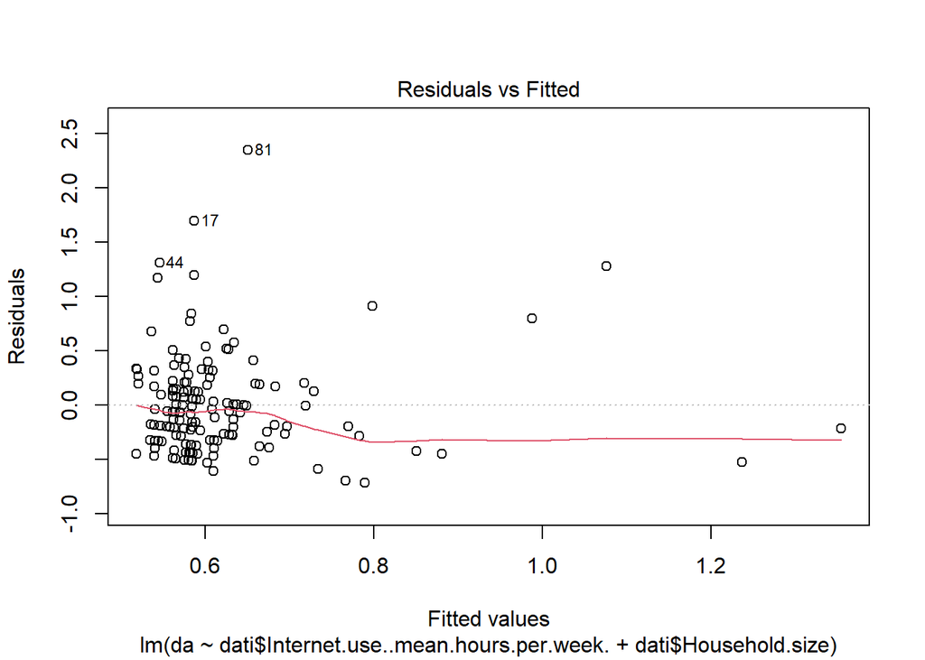

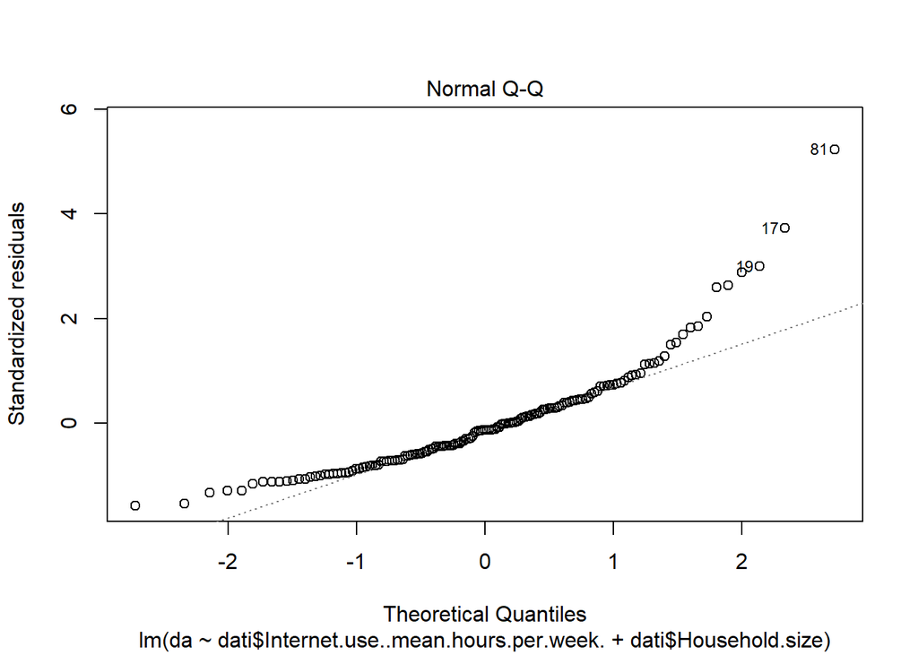

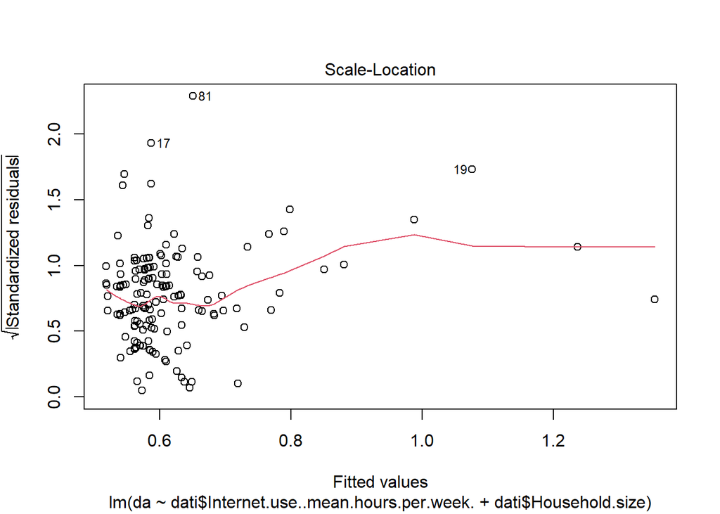

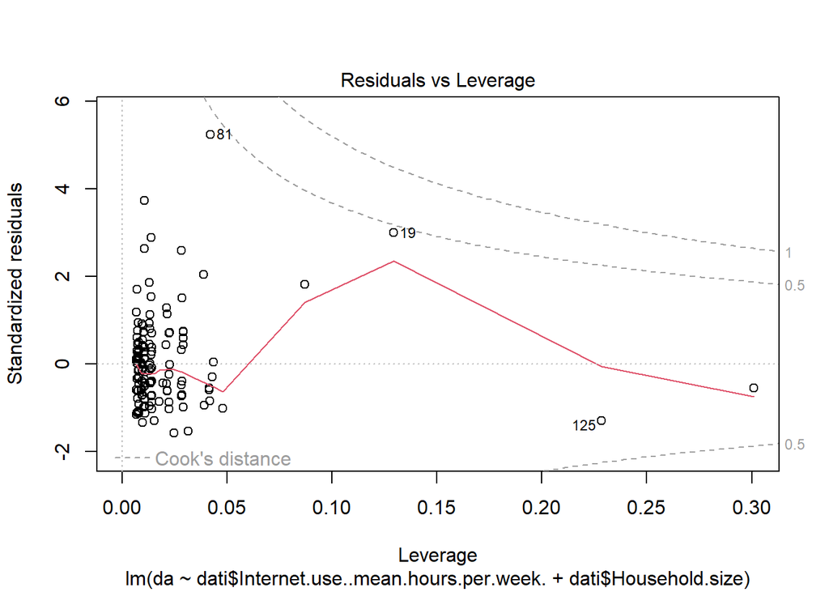

```r
plot(model25)
```

Como o p-value é menor do que 0.05, podemos rejeitar a H0, pelo que há evidencias que nos pode indicar uma correlação do grau de depressão com o número médio de horas de uso de internet por semana e o tamanho do agregado familiar do participante.

### Depressão com género e idade

H0: O grau de depressão depois do uso de internet não é correlacionado com o género e estágio de vida.  
H1: O grau de depressão depois do uso de internet é correlacionado com o género e estágio de vida.

```r
model26 = lm (da~dati$Gender+dati$Age)
model26
```

```
##
## Call:
## lm(formula = da ~ dati$Gender + dati$Age)
##
## Coefficients:
##     (Intercept)  dati$Gendermale     dati$AgeTeen
##         0.58763         -0.02154          0.14820
```

```r
summary(model26)
```

```
##
## Call:
## lm(formula = da ~ dati$Gender + dati$Age)
##
## Residuals:
##      Min       1Q   Median       3Q      Max
## -0.66440 -0.30192 -0.08763  0.14814  2.41237
##
## Coefficients:
##                 Estimate Std. Error t value Pr(>|t|)
## (Intercept)      0.58763    0.05552  10.583   <2e-16 ***
## dati$Gendermale -0.02154    0.07581  -0.284   0.7767
## dati$AgeTeen     0.14820    0.08669   1.710   0.0894 .
## ---
## Signif. codes:  0 '***' 0.001 '**' 0.01 '*' 0.05 '.' 0.1 ' ' 1
##
## Residual standard error: 0.4674 on 152 degrees of freedom
## Multiple R-squared:  0.01984,    Adjusted R-squared:  0.006947
## F-statistic: 1.539 on 2 and 152 DF,  p-value: 0.218
```

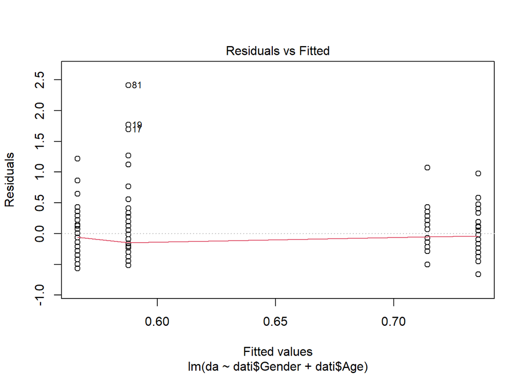

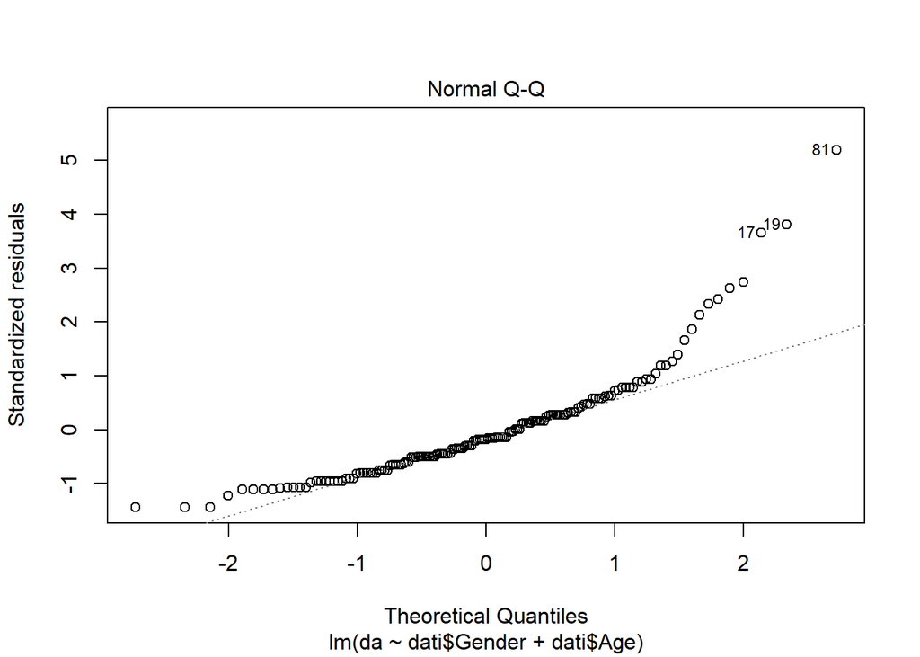

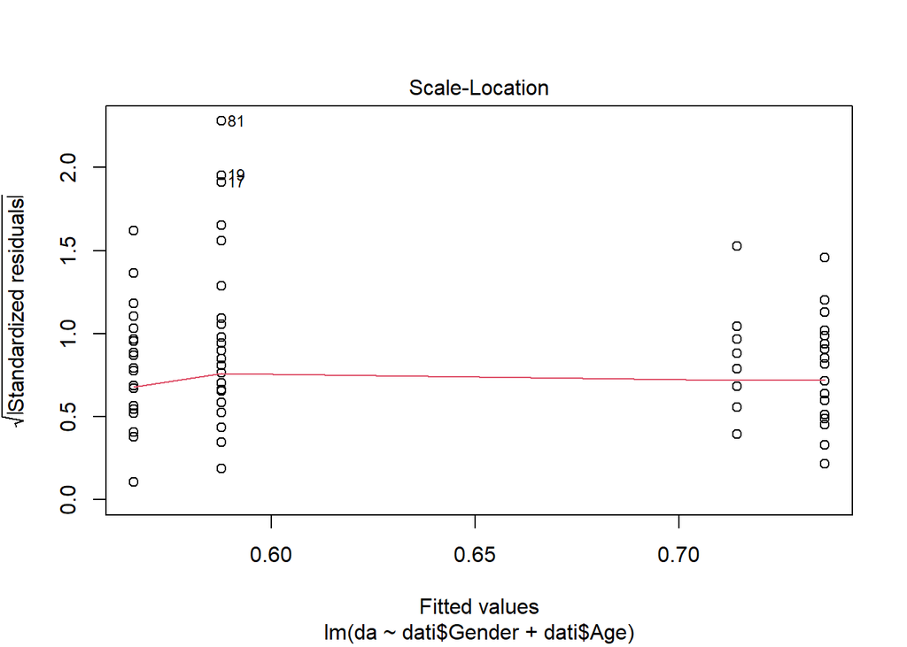

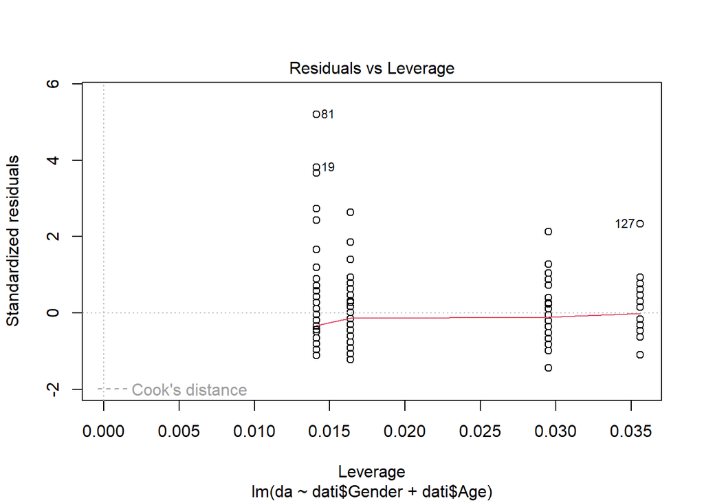

```r
plot(model26)
```

Como o p-value é maior do que 0.05, não podemos rejeitar a H0, pelo que há evidências que nos pode indicar que não há uma correlação do grau de depressão após o uso de internet com o género e estágio de vida

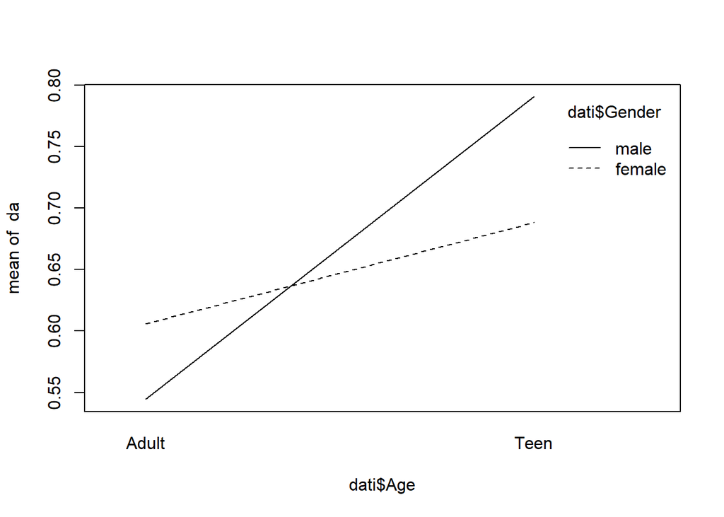

```r
interaction.plot(dati$Age,dati$Gender,da)
```

Apesar de não haver correlação entre o grau de depressão após o uso de internet com o género e o estágio de vida, é notavel pelo gráfico acima que existe uma interação entre estas variáveis.

### Depressão com género e etnia

H0: O grau de depressão depois do uso de internet não é correlacionado com o género e etnia.  
H1: O grau de depressão depois do uso de internet é correlacionado com o género e etnia.

```r
model27=lm(da~dati$Gender+dati$Race..white...1..minority...0.)
model27
```

```
##
## Call:
## lm(formula = da ~ dati$Gender + dati$Race..white...1..minority...0.)
##
## Coefficients:
##                         (Intercept)                      dati$Gendermale
##                            0.718198                            -0.002755
## dati$Race..white...1..minority...0.
##                           -0.130049
```

```r
summary(model27)
```

```
##
## Call:
## lm(formula = da ~ dati$Gender + dati$Race..white...1..minority...0.)
##
## Residuals:
##      Min       1Q   Median       3Q      Max
## -0.64677 -0.30244 -0.08539  0.13886  2.28180
##
## Coefficients:
##                                      Estimate Std. Error t value Pr(>|t|)
## (Intercept)                          0.718198   0.082022   8.756 3.65e-15 ***
## dati$Gendermale                     -0.002755   0.078364  -0.035    0.972
## dati$Race..white...1..minority...0. -0.130049   0.093972  -1.384    0.168
## ---
## Signif. codes:  0 '***' 0.001 '**' 0.01 '*' 0.05 '.' 0.1 ' ' 1
##
## Residual standard error: 0.4689 on 152 degrees of freedom
## Multiple R-squared:  0.01343,    Adjusted R-squared:  0.0004452
## F-statistic: 1.034 on 2 and 152 DF,  p-value: 0.358
```

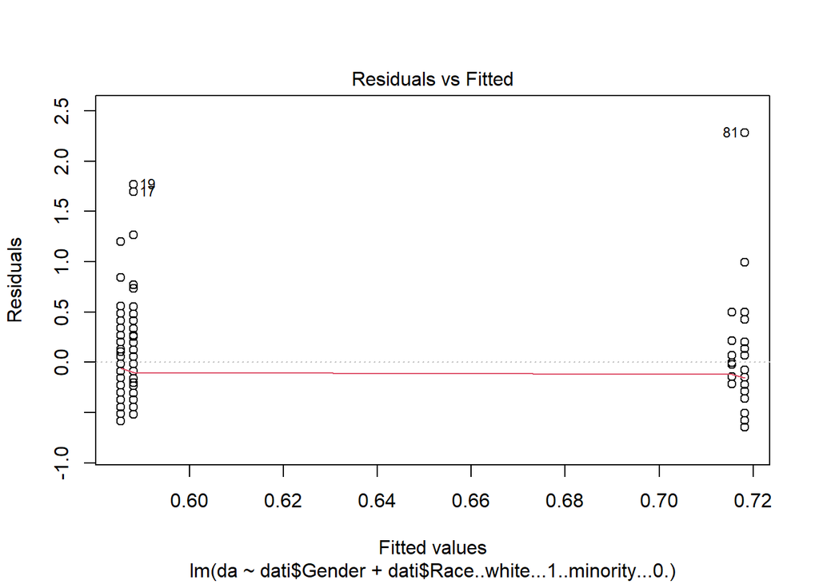

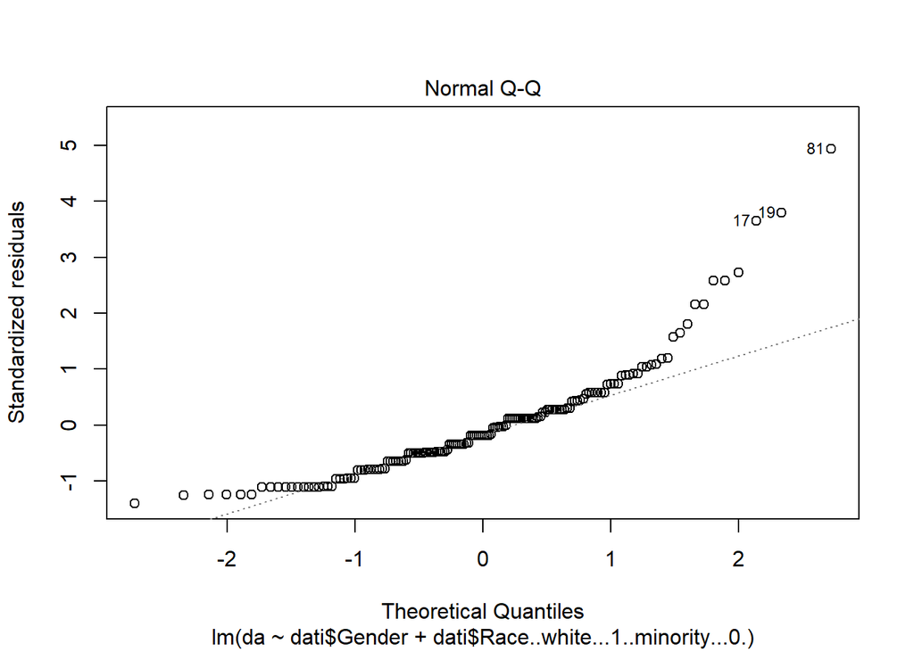

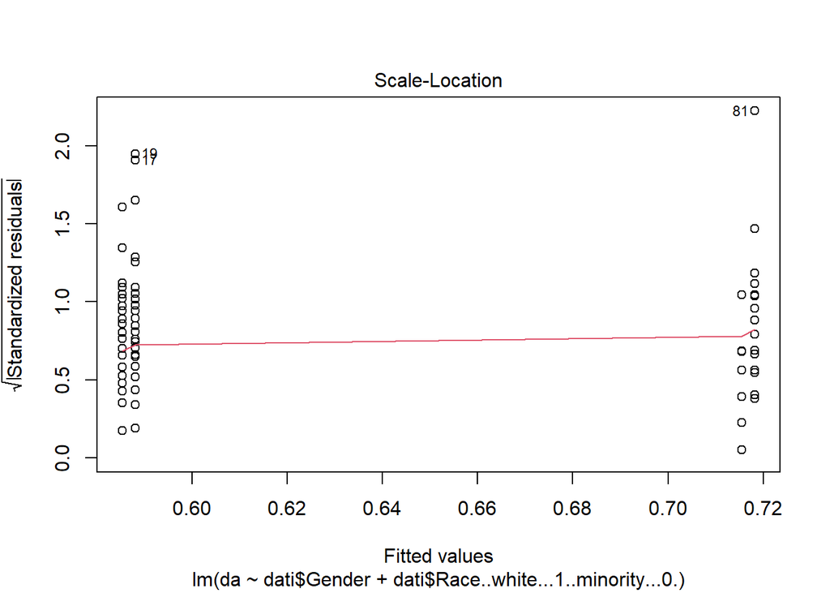

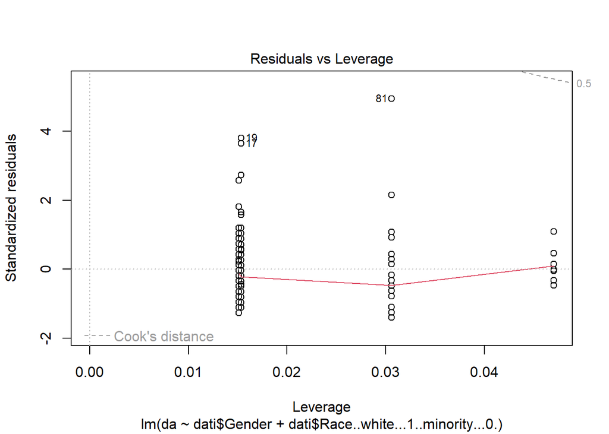

```r
plot(model27)
```

Como o p-value é maior do que 0.05, não podemos rejeitar a H0, pelo que há evidências que nos pode indicar que não há uma correlação do grau de depressão com o género e etnia.

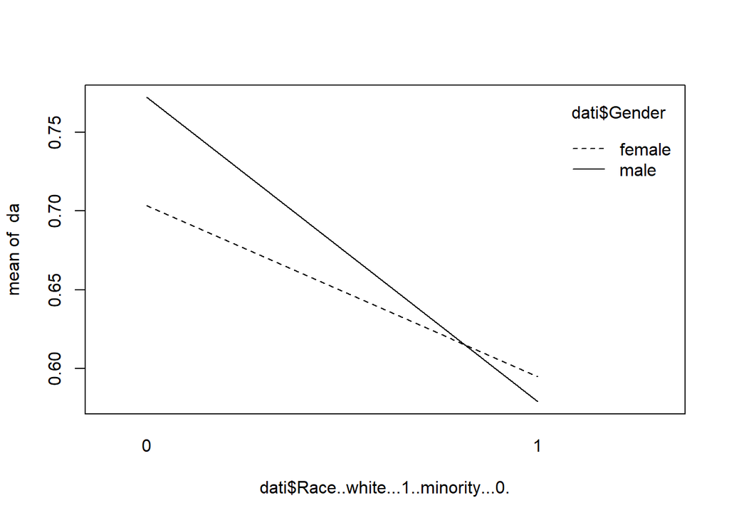

```r
interaction.plot(dati$Race..white...1..minority...0.,dati$Gender,da)
```

Apesar de não haver correlação entre o grau de depressão após o uso de internet com o género e a etnia é notável pelo gráfico acima que existe uma interação entre estas variáveis.

### Depressão com idade e etnia

H0: O grau de depressão depois do uso de internet não é correlacionado com o estágio de vida e a etnia.  
H1: O grau de depressão depois do uso de internet é correlacionado com o estágio de vida e a etnia.

```r
model28 =lm(da ~dati$Age+dati$Race..white...1..minority...0.)
model28
```

```
##
## Call:
## lm(formula = da ~ dati$Age + dati$Race..white...1..minority...0.)
##
## Coefficients:
##                         (Intercept)                         dati$AgeTeen
##                              0.6929                               0.1684
## dati$Race..white...1..minority...0.
##                             -0.1534
```

```r
summary(model28)
```

```
##
## Call:
## lm(formula = da ~ dati$Age + dati$Race..white...1..minority...0.)
##
## Residuals:
##      Min       1Q   Median       3Q      Max
## -0.78988 -0.30226 -0.06505  0.16950  2.30714
##
## Coefficients:
##                                     Estimate Std. Error t value Pr(>|t|)
## (Intercept)                          0.69286    0.08044   8.613 8.47e-15 ***
## dati$AgeTeen                         0.16845    0.08644   1.949   0.0532 .
## dati$Race..white...1..minority...0. -0.15343    0.09065  -1.693   0.0926 .
## ---
## Signif. codes:  0 '***' 0.001 '**' 0.01 '*' 0.05 '.' 0.1 ' ' 1
##
## Residual standard error: 0.4632 on 152 degrees of freedom
## Multiple R-squared:  0.03747,    Adjusted R-squared:  0.0248
## F-statistic: 2.958 on 2 and 152 DF,  p-value: 0.05491
```

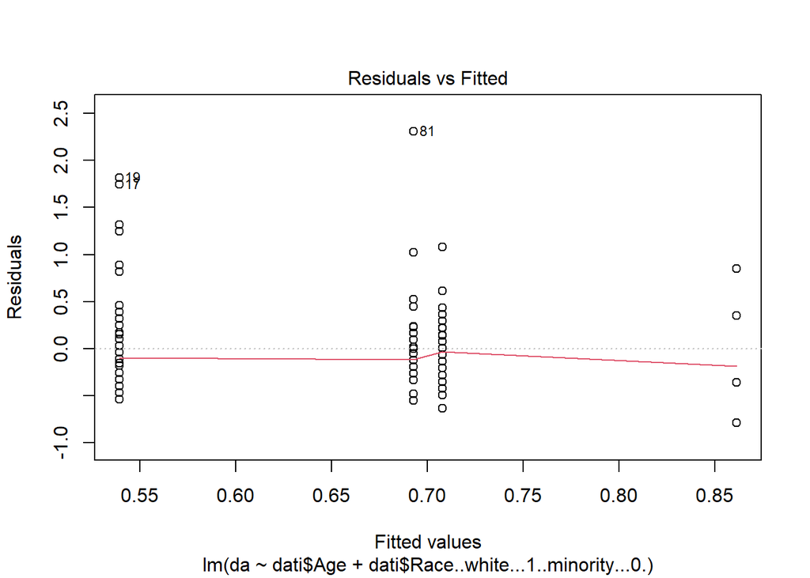

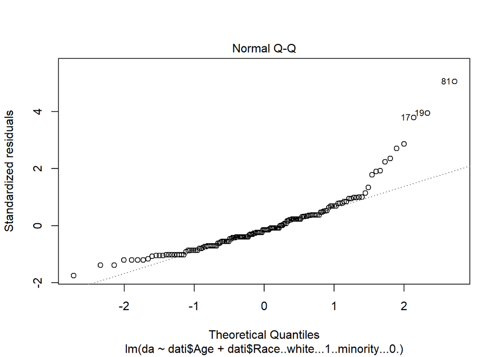

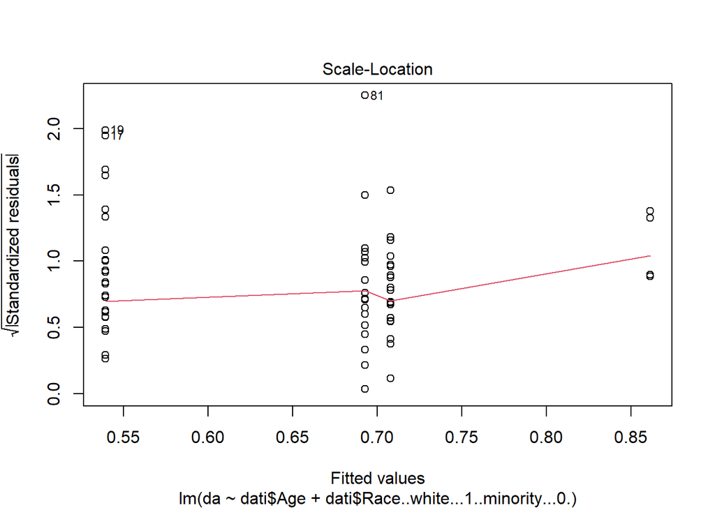

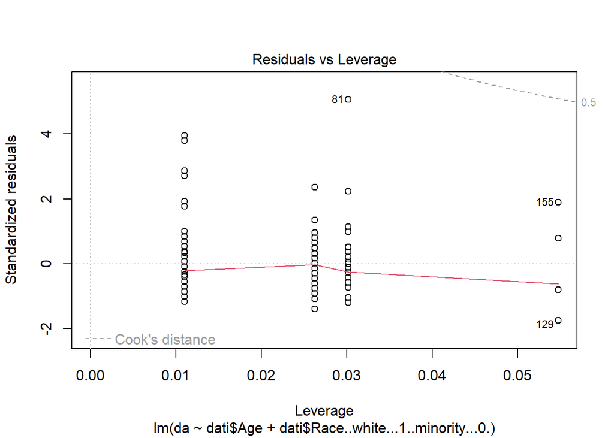

```r
plot(model28)
```

Como o p-value é maior do que 0.05, não podemos rejeitar a H0, pelo que há evidências que nos pode indicar que não há uma correlação do grau de depressão apos o uso de internet com o estágio de vida e a etnia.

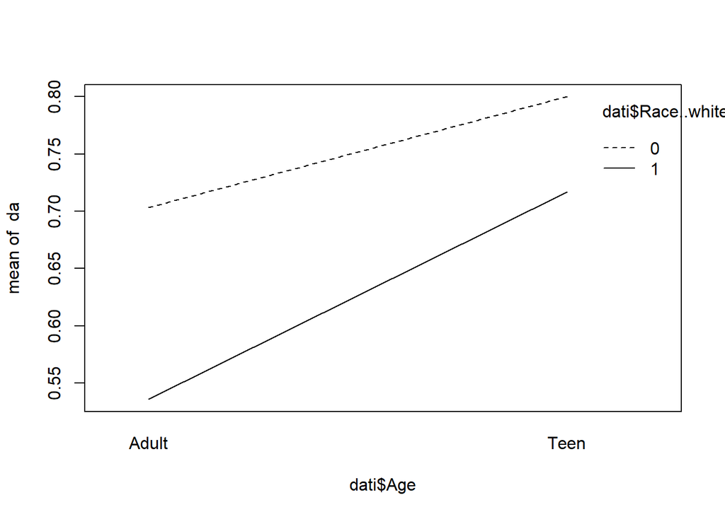

```r
interaction.plot(dati$Age,dati$Race..white...1..minority...0.,da)
```

Para além de não haver correrlação, este gráfico demonstra que não existe interação entre estas variáveis.

## Depression Before

### Depressão com género e idade

H0: O grau de depressão antes do uso de internet não é correlacionado com o género e idade.  
H1: O grau de depressão antes do uso de internet é correlacionado com o género e idade.

```r
model26 = lm (db~dati$Gender+dati$Age)
model26
```

```
##
## Call:
## lm(formula = db ~ dati$Gender + dati$Age)
##
## Coefficients:
##     (Intercept)  dati$Gendermale     dati$AgeTeen
##         0.65833         -0.04977          0.38637
```

```r
summary(model26)
```

```
##
## Call:
## lm(formula = db ~ dati$Gender + dati$Age)
##
## Residuals:
##      Min       1Q   Median       3Q      Max
## -0.92827 -0.32502 -0.07524  0.23995  1.48849
##
## Coefficients:
##                 Estimate Std. Error t value Pr(>|t|)
## (Intercept)      0.65833    0.05567  11.825  < 2e-16 ***
## dati$Gendermale -0.04977    0.07601  -0.655    0.514
## dati$AgeTeen     0.38637    0.08692   4.445 1.69e-05 ***
## ---
## Signif. codes:  0 '***' 0.001 '**' 0.01 '*' 0.05 '.' 0.1 ' ' 1
##
## Residual standard error: 0.4687 on 152 degrees of freedom
## Multiple R-squared:  0.1195, Adjusted R-squared:  0.108
## F-statistic: 10.32 on 2 and 152 DF,  p-value: 6.278e-05
```

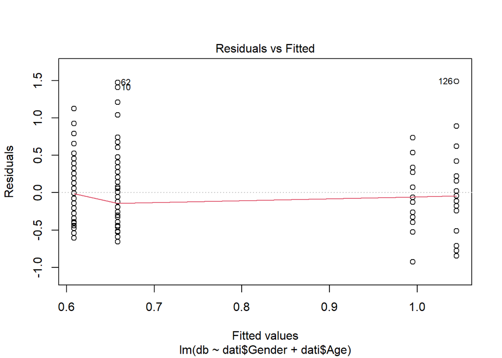

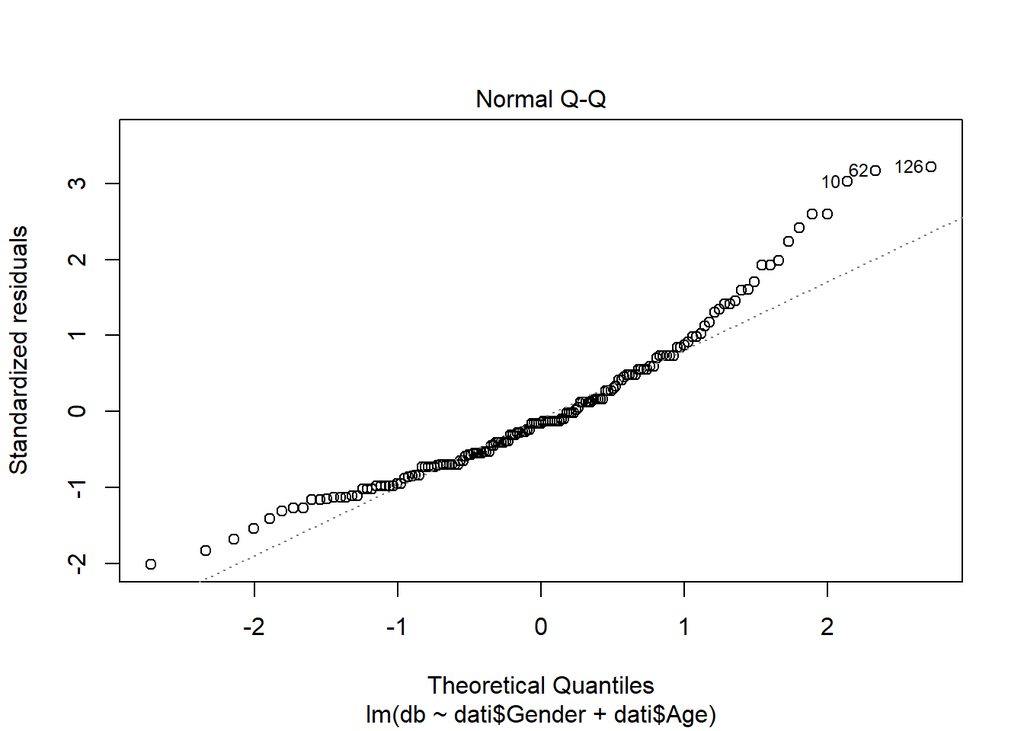

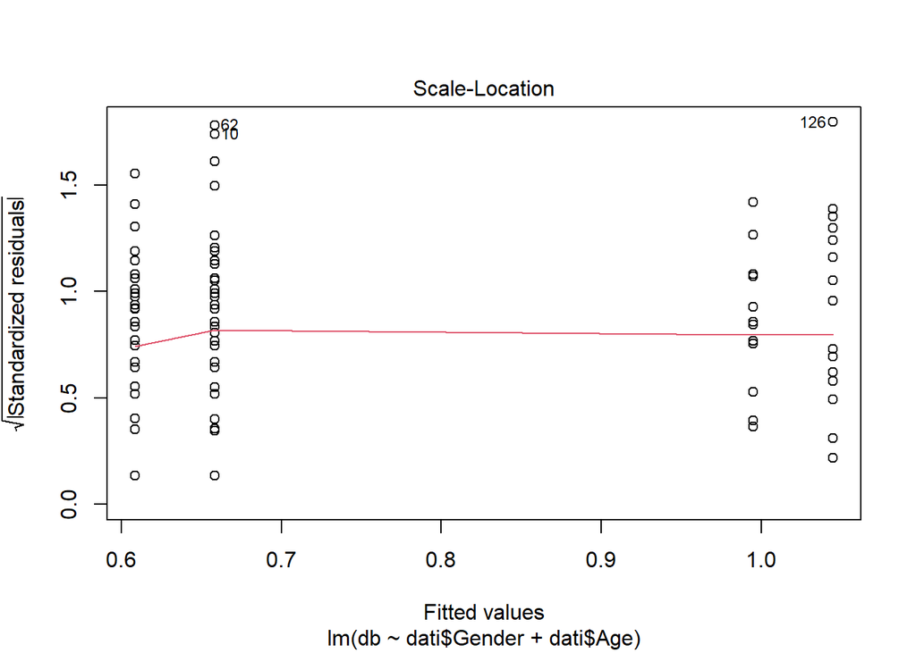

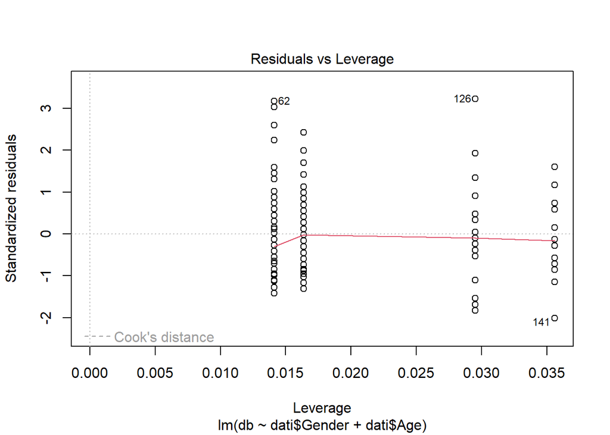

```r
plot(model26)
```

Como o p-value é menor do que 0.05, rejeitamos H0, pelo que há evidências que nos pode indicar a existência de uma correlação do grau de depressão antes do uso de internet com o genero e o estágio de vida.

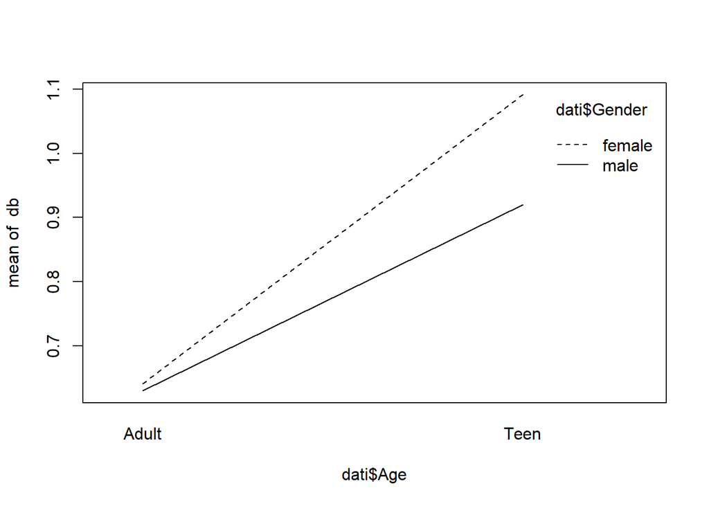

```r
interaction.plot(dati$Age,dati$Gender,db)
```

Apesar de existir uma correlação este grafico indica que não existe nenhuma interação entre as variáveis.

### Depressão com género e etnia

H0: O grau de depressão antes do uso de internet não é correlacionado com o género e etnia.  
H1: O grau de depressão antes do uso de internet é correlacionado com o género e etnia.

```r
model27=lm(db~dati$Gender+dati$Race..white...1..minority...0.)
model27
```

```
##
## Call:
## lm(formula = db ~ dati$Gender + dati$Race..white...1..minority...0.)
##
## Coefficients:
##                         (Intercept)                      dati$Gendermale
##                             0.71701                             -0.08554
## dati$Race..white...1..minority...0.
##                             0.06947
```

```r
summary(model27)
```

```
##
## Call:
## lm(formula = db ~ dati$Gender + dati$Race..white...1..minority...0.)
##
## Residuals:
##     Min      1Q  Median      3Q     Max
## -0.7198 -0.3851 -0.0532  0.2576  1.7467
##
## Coefficients:
##                                     Estimate Std. Error t value Pr(>|t|)
## (Intercept)                          0.71701    0.08700   8.241 7.37e-14 ***
## dati$Gendermale                     -0.08554    0.08312  -1.029    0.305
## dati$Race..white...1..minority...0.  0.06947    0.09968   0.697    0.487
## ---
## Signif. codes:  0 '***' 0.001 '**' 0.01 '*' 0.05 '.' 0.1 ' ' 1
##
## Residual standard error: 0.4974 on 152 degrees of freedom
## Multiple R-squared:  0.008261,   Adjusted R-squared:  -0.004788
## F-statistic: 0.6331 on 2 and 152 DF,  p-value: 0.5323
```

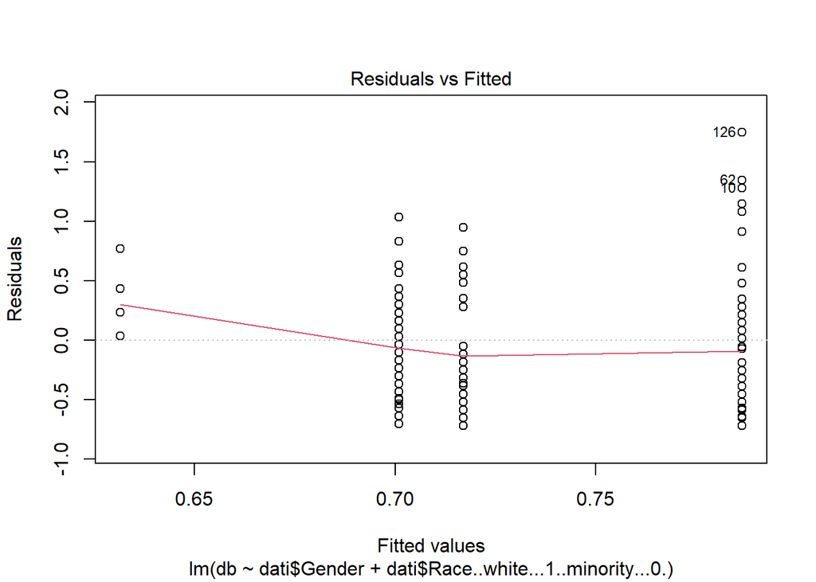

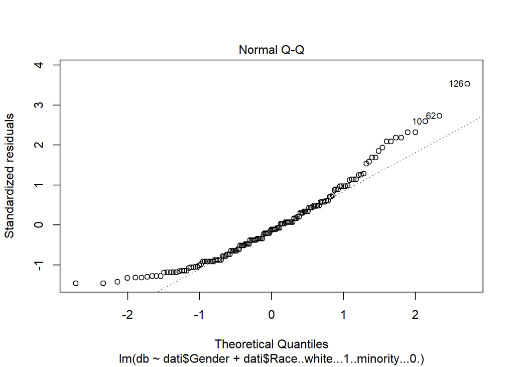

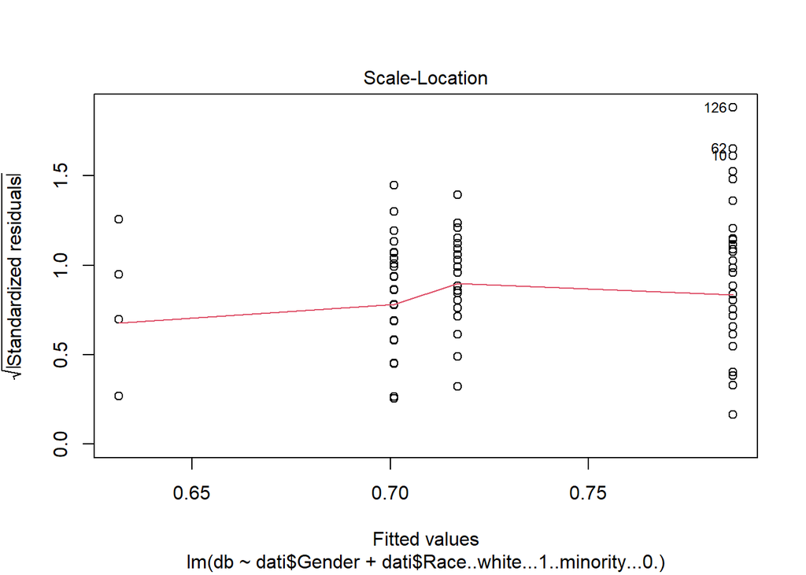

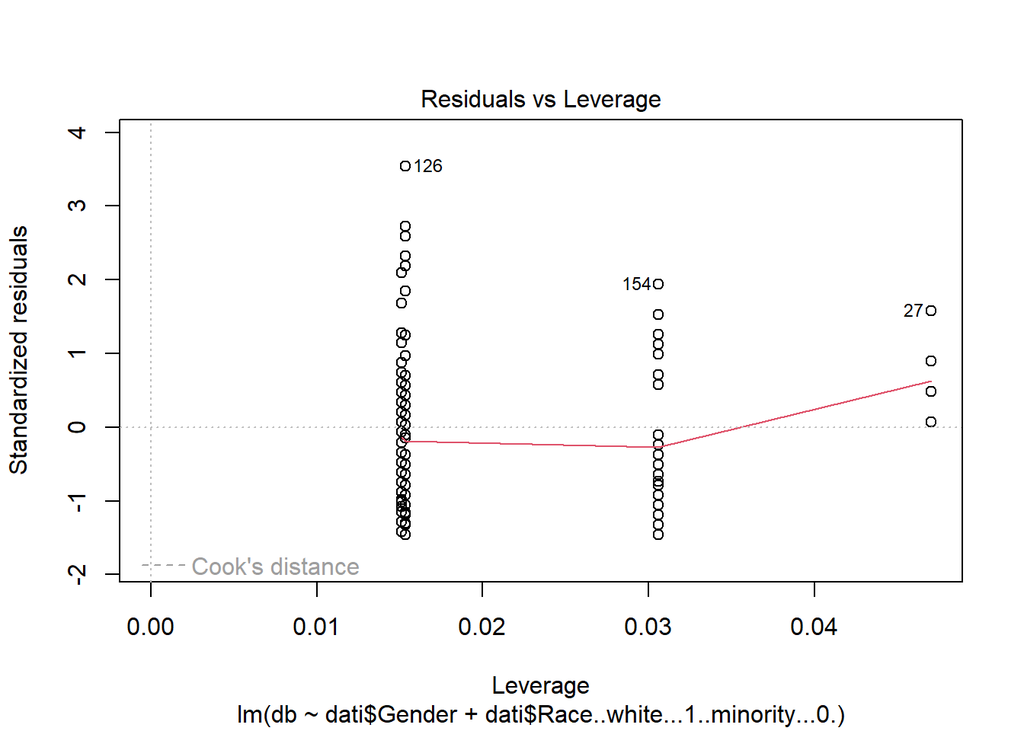

```r
plot(model27)
```

Como o p-value é maior do que 0.05, não podemos rejeitar a H0, pelo que há evidências que nos pode indicar que não há uma correlação do grau de depressão antes do uso de internet com o género e a etnia.

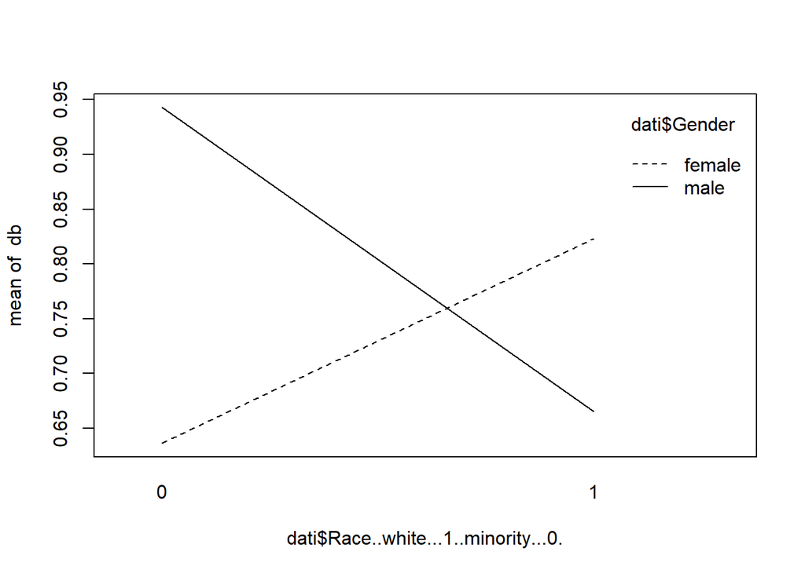

```r
interaction.plot(dati$Race..white...1..minority...0.,dati$Gender,db)
```

Porém apesar de existirem evidências de não haver correlação, este gráfico demontra a existencia de uma interação entre as variaveis.

### Depressão com idade e etnia

H0: O grau de depressão antes do uso de internet não é correlacionado com o idade e etnia.  
H1: O grau de depressão antes do uso de internet é correlacionado com o idade e etnia.

```r
model28 =lm(db ~dati$Age+dati$Race..white...1..minority...0.)
model28
```

```
##
## Call:
## lm(formula = db ~ dati$Age + dati$Race..white...1..minority...0.)
##
## Coefficients:
##                         (Intercept)                         dati$AgeTeen
##                            0.641902                             0.390997
## dati$Race..white...1..minority...0.
##                           -0.008411
```

```r
summary(model28)
```

```
##
## Call:
## lm(formula = db ~ dati$Age + dati$Race..white...1..minority...0.)
##
## Residuals:
##      Min       1Q   Median       3Q      Max
## -0.95782 -0.30438 -0.09126  0.23339  1.50872
##
## Coefficients:
##                                      Estimate Std. Error t value Pr(>|t|)
## (Intercept)                          0.641902   0.081510   7.875 6.00e-13 ***
## dati$AgeTeen                         0.390997   0.087586   4.464 1.56e-05 ***
## dati$Race..white...1..minority...0. -0.008411   0.091846  -0.092    0.927
## ---
## Signif. codes:  0 '***' 0.001 '**' 0.01 '*' 0.05 '.' 0.1 ' ' 1
##
## Residual standard error: 0.4693 on 152 degrees of freedom
## Multiple R-squared:  0.1171, Adjusted R-squared:  0.1055
## F-statistic: 10.08 on 2 and 152 DF,  p-value: 7.744e-05
```

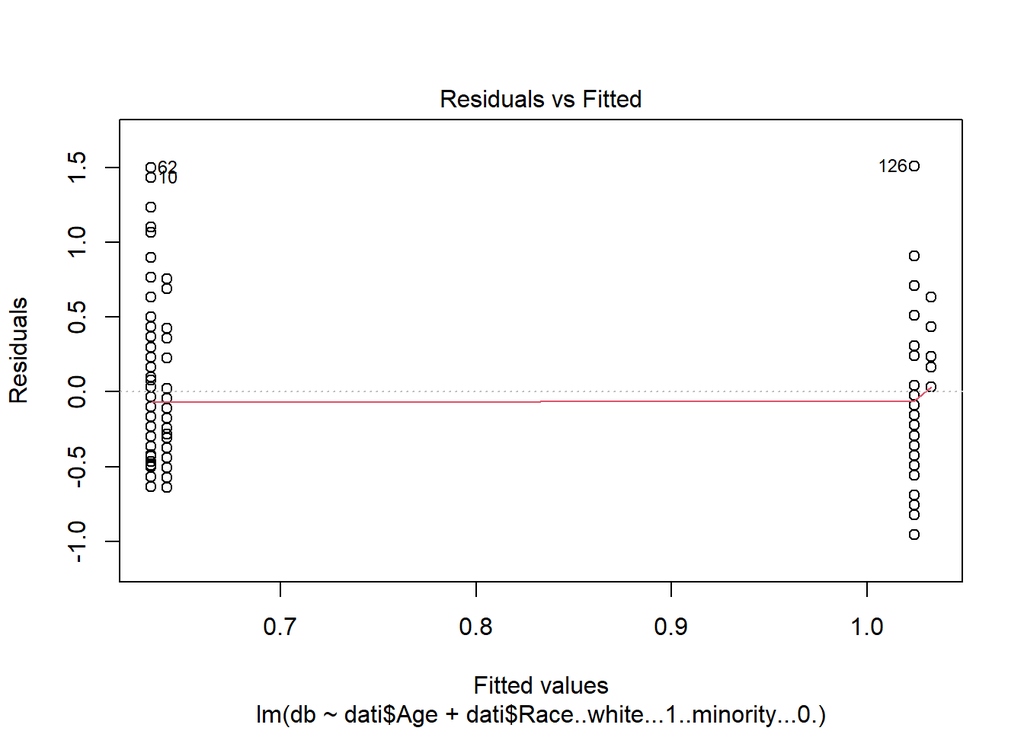

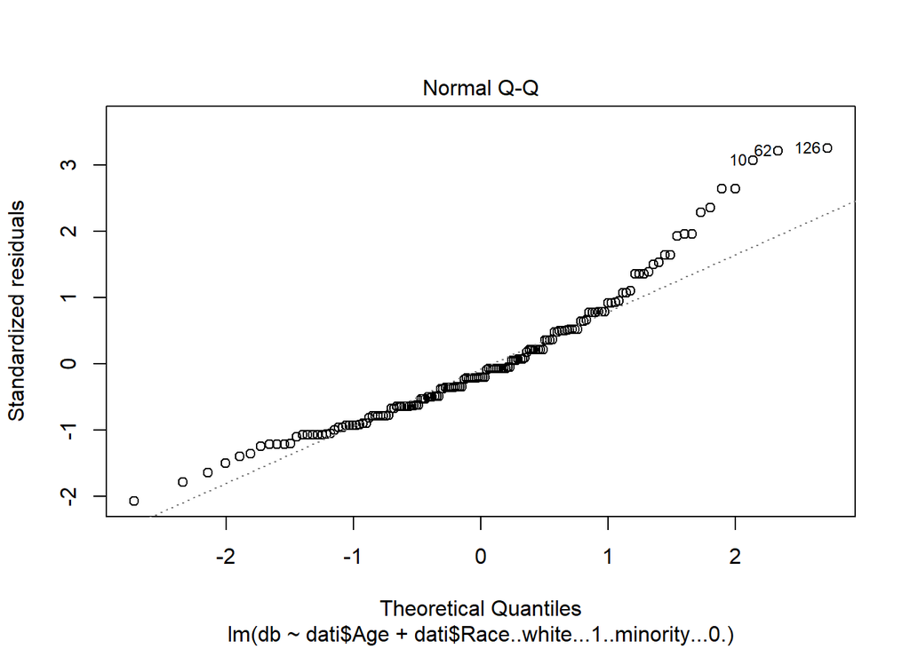

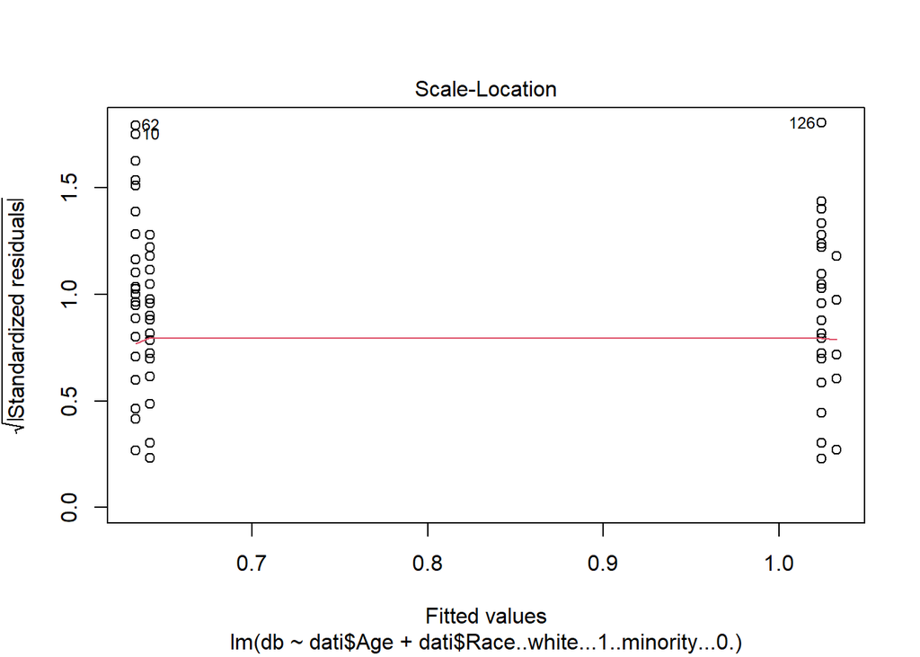

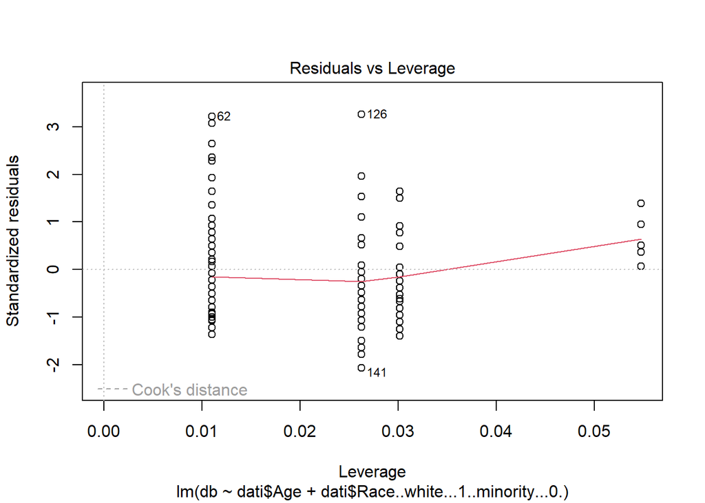

```r
plot(model28)
```

Como o p-value é menor do que 0.05, rejeitamos H0, pelo que há evidências que nos pode indicar a existência de uma correlação do grau de depressão antes do uso de internet com o estágio de vida e a etnia.

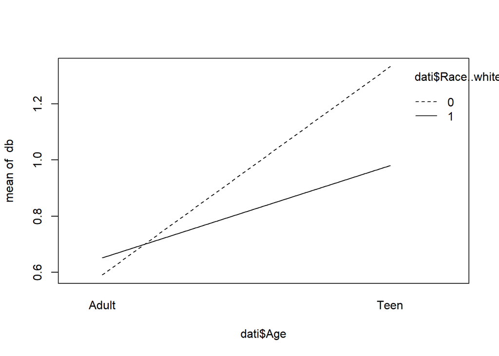

```r
interaction.plot(dati$Age,dati$Race..white...1..minority...0.,db)
```